# Predicting Loan Defaults with Logistic Regression

Benjamin J. Anderson

Chippewa Valley Dev Group

## Executive Summary

The results show that our models, though excellent at predicting loans that are not in risk of default, are poor when it comes to predicting loans that have defaulted due to unbalanced training data. A balanced model was constructed utilizing the same variables as our initial model, finding it performed significantly worse than our initial model at the same threshold. Ignoring specificity and sensitivity, the maximum accuracy is achieved at a threshold of 0.05 – resulting with a prediction accuracy of 77.8%. At a threshold level of 0.25, or model had a false-positive rate of 8% with a net profit of $3,100,486 and an accuracy of 73.3%.

## 1. Introduction

A bank would like to predict which loan applicants who are likely to default. The bank has provided a sample of 50,000 loan applications and their current status; “DEFAULT”, “CURRENT”, “CHARGED OFF”. A logistic regression model will be utilized to augment the banks loan application and review process. Several logistic regression models will be tested with a range of predictor variable in an attempt to identify the best performing model suiting the goals of the bank with the dataset provided.

## 3. Preparing and Cleaning the Data

The bank has provided a sample of 50,000 loan applications, containing 30 fields for each record. Not all of the fields are intuitively useful for the logistic regression model and the data was santized.

# 3.2 Loan Status Preparation

# 3.3 Exclusion of Irrelevant Variables

On initial review of the dataset, the following variables were excluded from the dataset:

1. **loanID**: This unique identifier, though relevant to the bank, is not needed by our model to predict which loans may default.
2. **employment**: Though being employed is a significant factor when approving a loan, this dataset also contains income, which is allows us to assume employment if larger than zero.
3. **totalPaid**: This variable can only be determined after a loan has been issued and will be excluded from the test data.
4. **state**: The state of the bank / applicant isn’t expect to impact the applicants ability to manage payments on a loan.

Other considerations were taken for the following variables, but were kept due to the following:

1. **reason**: Different types of loans may contribute to the likelihood of defaulting.
2. **verified**: If the income hasn’t been verified and an applicant has lied on the application, the applicant may default on the loan if they cannot afford the payments.

# 3.4 Grouping of Categorical Variables

The length of employment may be a contributing factor as to how long an applicant may be able to pay for a loan. For example, employees who’ve worked with a comapny for a significant amount of time show that they have a stable income whereas those who have worked with an employer for only a few years may not reflect stability.

The length of employment is categorized from less than 1 year and to 10+ years, with 2680 not applicable “n/a” records. Such situations being classified as “n/a” may include retirement or being unemployed. The employment length field has been changed to be categorized as:

- missing
- < 1 year
- 1 to 3 years
- 4 to 6 years
- 7 to 9 years
- 10+ years

Resulting with the following categories:

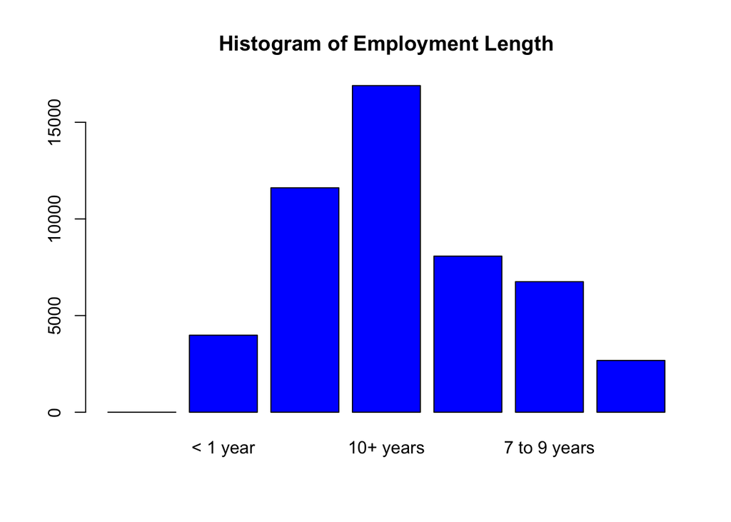

```
##                  < 1 year 1 to 3 years    10+ years 4 to 6 years
##            1         3985        11610        16896         8075
## 7 to 9 years      missing
##         6753         2680
```

Income was also categorized into 7 brackets based off the US tax brackets for 2019.

- < 9700
- 9700 - 39475
- 39476 - 84200
- 84200 - 160725
- 160726 - 204101
- 204102 - 510300
- > 510300

# 3.5 Removal of Records

Loans that are currently being paid off, late, or in grace period have been removed from the data. These records may be in risk of default or may be fully paid in the future, but have yet to be converted to that status, thus irrelevant for our model. Records missing the loan amount, rate, payment, and income were also removed. This resulted in 34, 916 records in our sample.

This resulted in bcOpen having 363 missing records, bcRatio having 388, and revolRatio with 15.

# 3.6.1 Revolving Credit Ratio

The proportion of revolving credit in use, “revolRation”, is anticipated to have some impact on our response variable as revolving credit affects an applicants ability to pay larger loans and interest rates. Considering that there are only 15 records in the entire sample with missing values, it is anticipated that there will be minimal effects to imputing these records from the dataset.

# 3.6.2 Credit Card Use and Ratio

The ability of an applicant to make payments on a new loan is expected to be affected by current credit card balances unless the loan is to consolidate credit card debt. Due to the missing credit card open credit amount, “bcOpen”, and credit card debt ratio, “bcRatio”, impacting a maximum of 2% of the sample. These missing values have been inferred by the median value.

## 4. Exporing and Transforming the Data

Logistic Regression models do not require a normal distribution for the predictor variables, however, a skewed predictor variable is likely to have extreme values that will influence the resulting model. Several predictor variables were selected based on their anticipated statistical significance.

# 4.1 Income

One major contributing factor to the ability to pay off loans is to have an income.

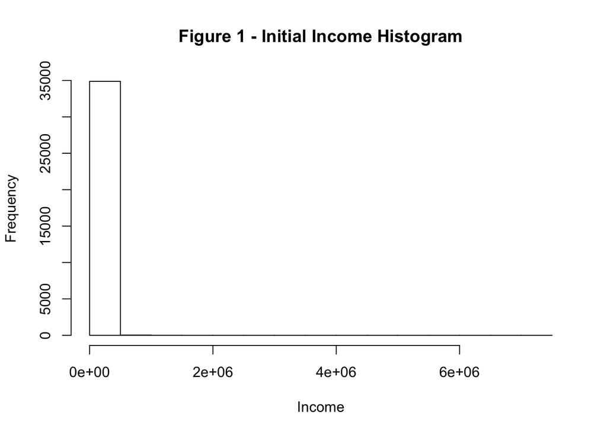

The income histogram immediately depicts that there are some extreme values, making this data appear right-skewed. The Z-Score’s for the income field depict that the median is -0.1604 standard deviations away from the mean, but the maximum value is 115.5 standard deviations; suggesting we have some outliers to either: remove, inferr, or possibly turn income into a categorical variable depicting income range.

```
##     Min.  1st Qu.   Median     Mean  3rd Qu.     Max.
##  -1.1160  -0.4658  -0.1604   0.0000   0.2313 115.5000
```

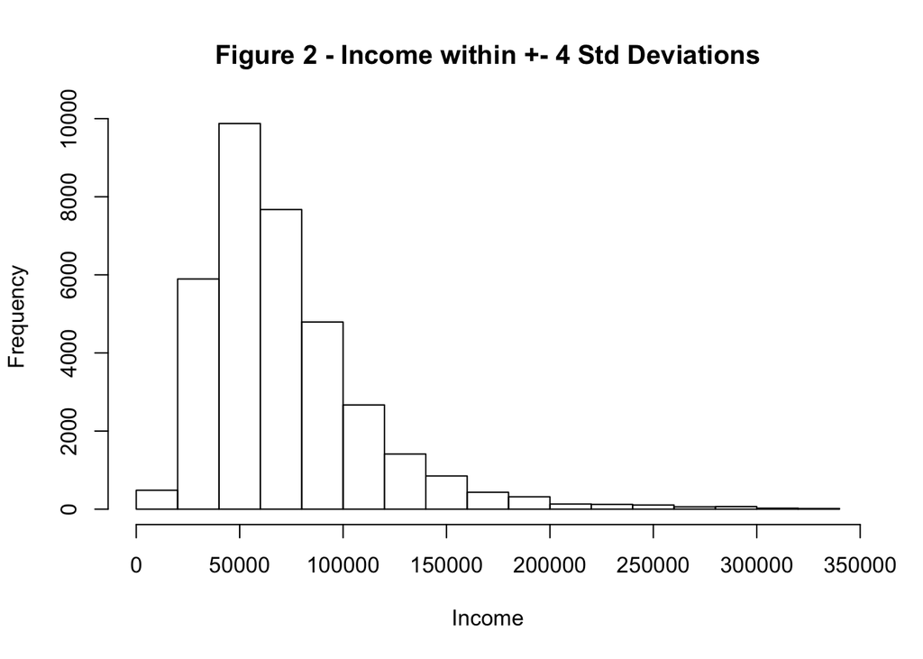

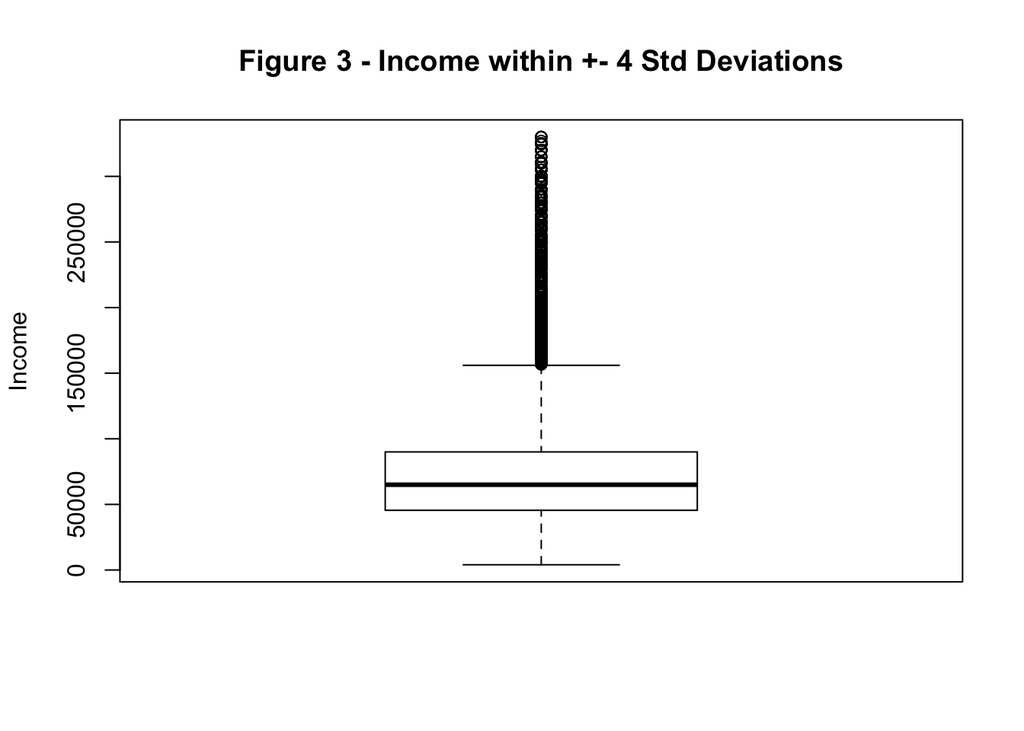

Omitting 134 containing income within +- 4 standard deviations from the mean and converting them to NA values, we can see that our income sample is right-skewed. In attempt to normalize the data and reduce the extremeness of the tail, depicted in the boxplot in figure 3, the square root was applied to the income field and stored in a separate column “income_sqrt”. Figure 4 reflects the application of the square root function, depicting a normal distribution.

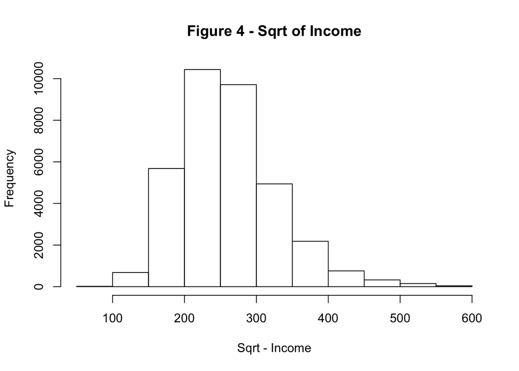

# 4.2 Loan Amount

The loan amount is anticipated to be statistically significant due to larger loans requiring a larger income. Those with a large amount of debt and small income may not be able to pay of larger loan amounts. Figure 5 and the associated Q-Q Plot depicts an under-dispersed dataset due to the outliers toward the right tail, but otherwise reflects a right-skewed dataset.

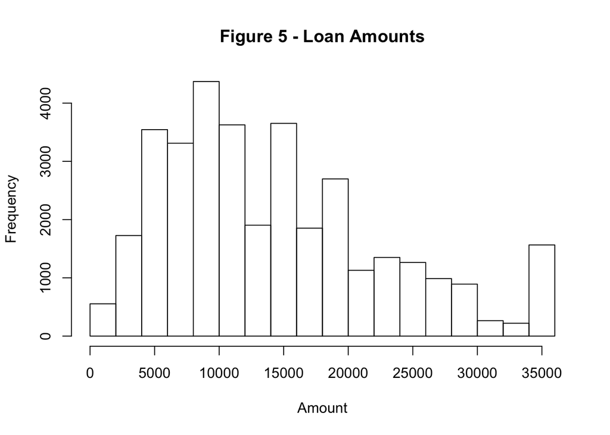

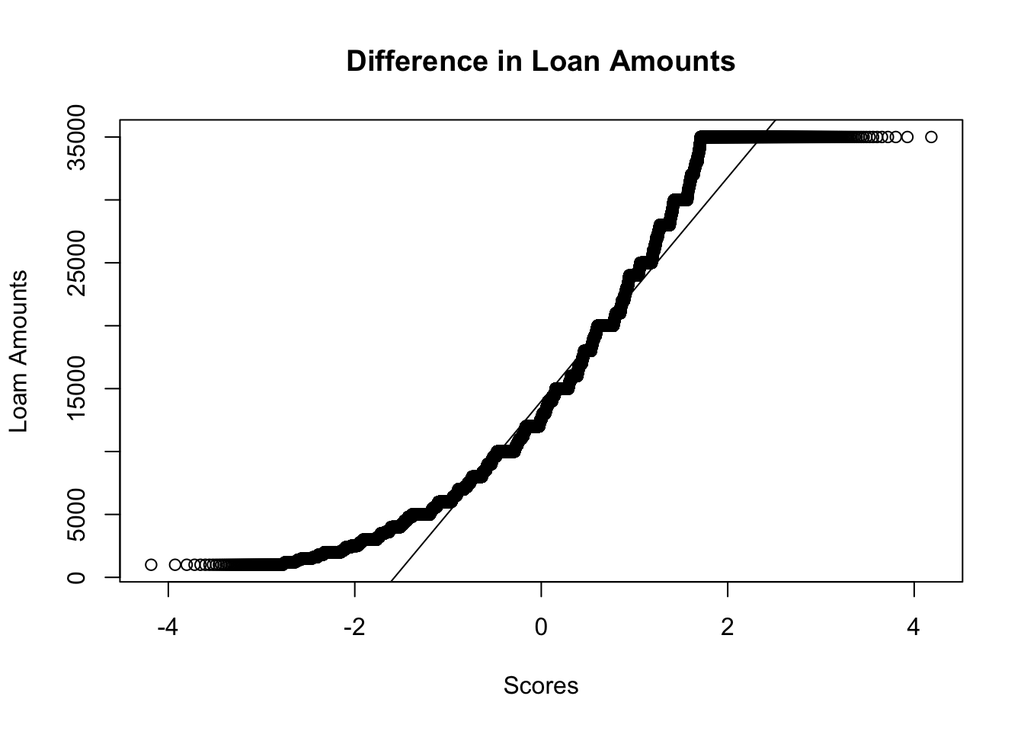

Taking the square root of the loan amount and saving the result to a column “amount_sqrt” resulted in a more normal distribution with no outliers depicted in the boxpolot in Figure 6.

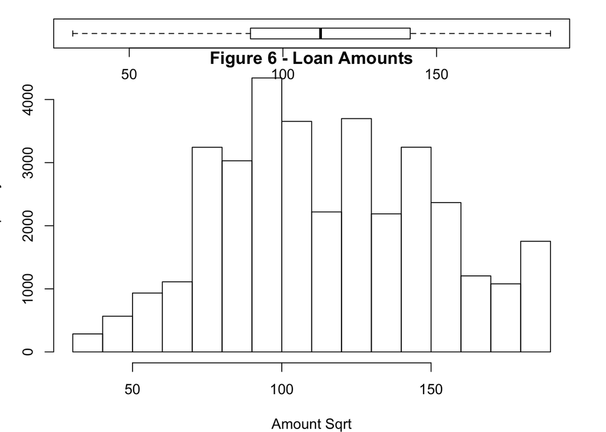

# 4.3 Explorations

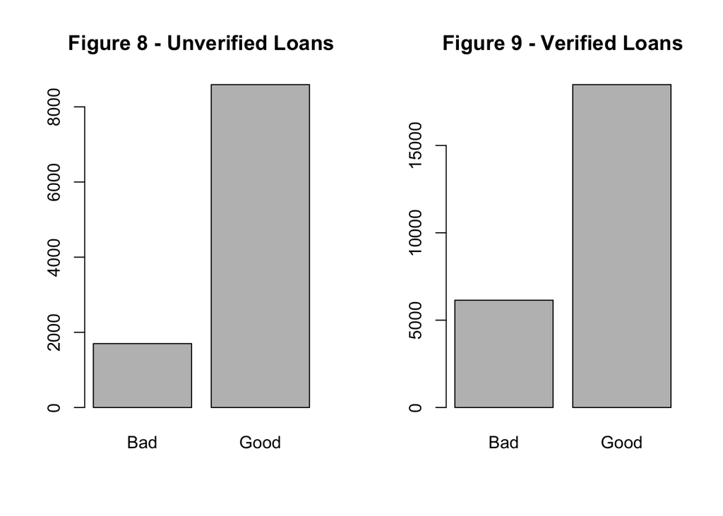

# 4.3.1 Reason Behind the Loan

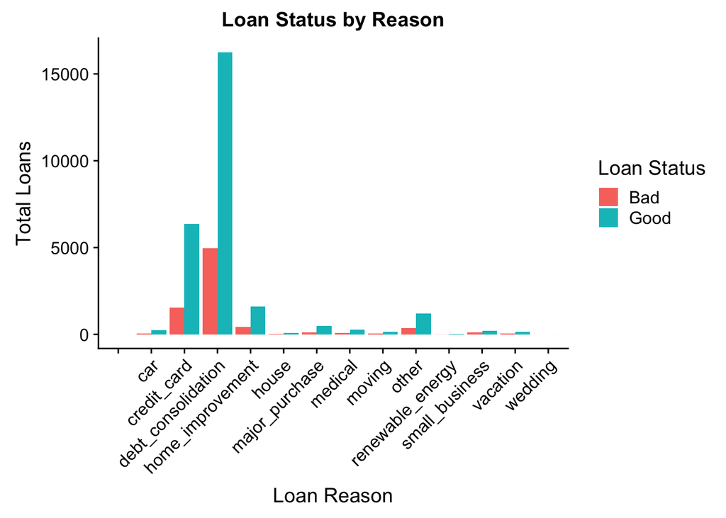

# 4.3.2 Debt Ratio without Mortgage

```
##
##               Bad  Good
##   < 10%       992  4912
##   10% - 25%  4443 16629
##   25% - 33%  1747  4388
##   33% - 50%   659  1145
##   50% - 66%     1     0
```

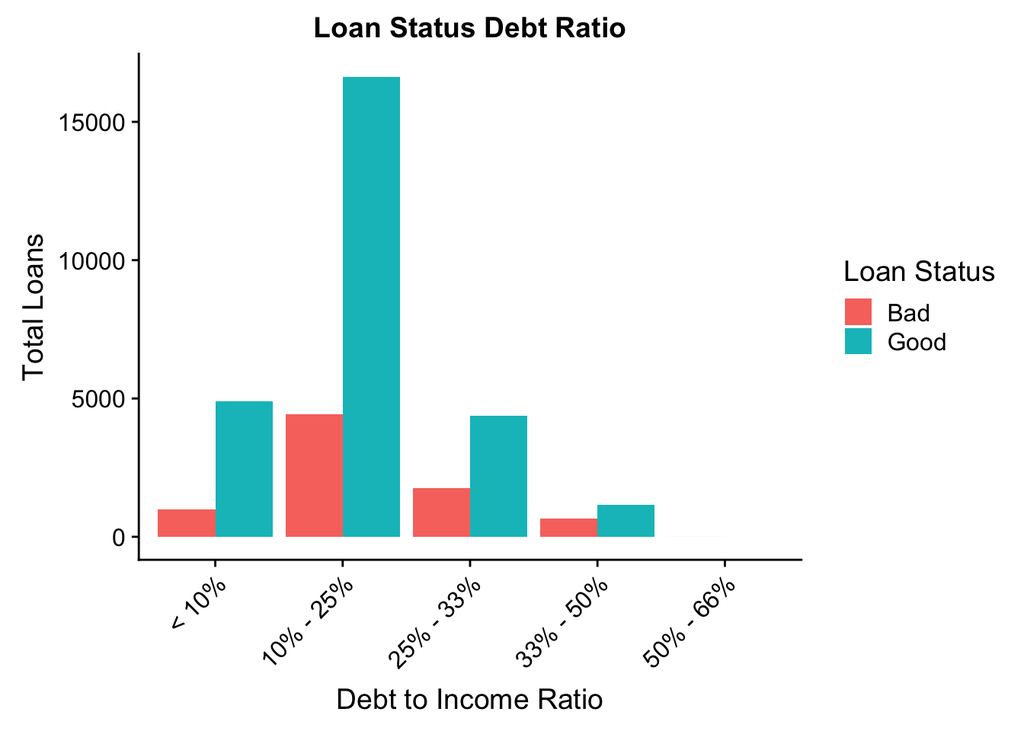

# 4.3.3 Other Potential Predictors

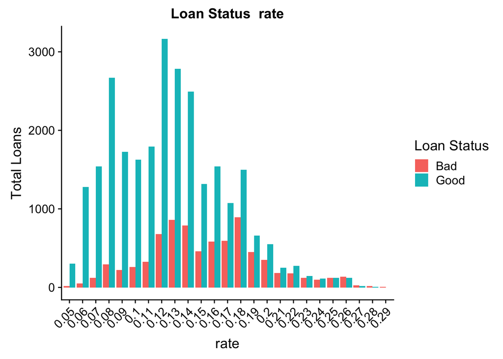

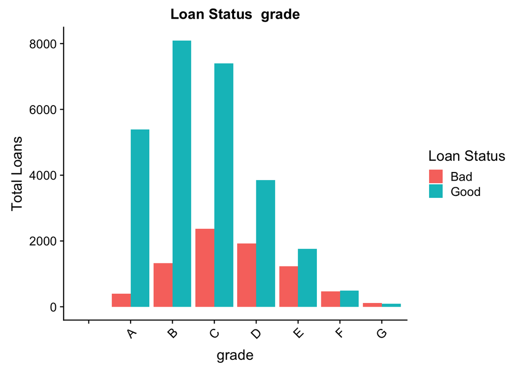

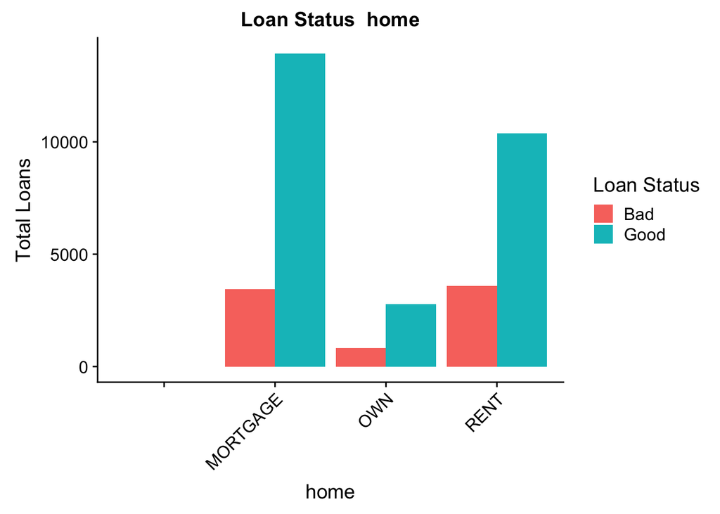

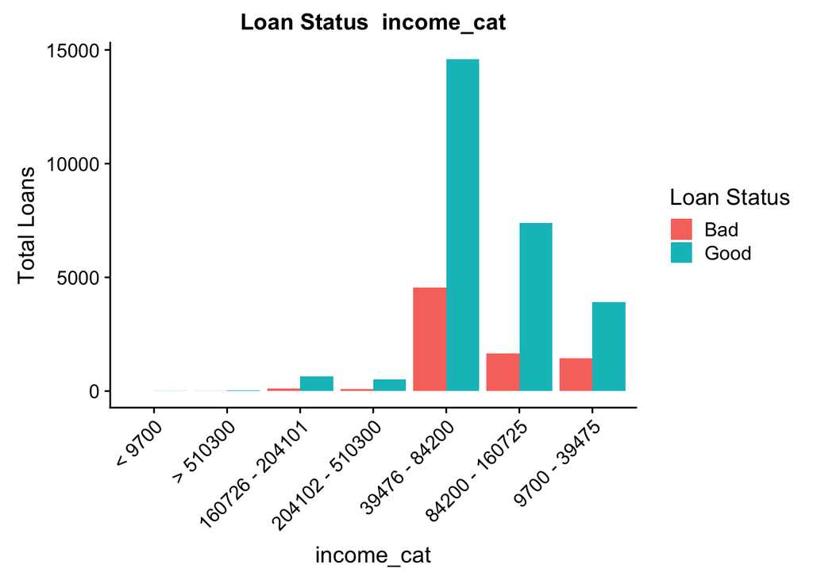

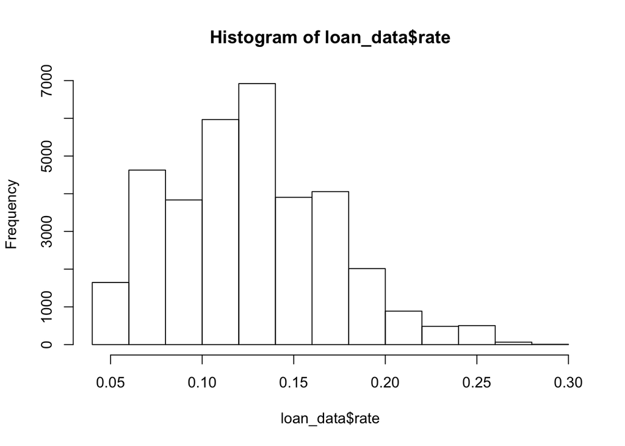

```
## [1] 0.05 0.10 0.13 0.16 0.29
```

# 4.3.5 Collinearity

Before creating our logistic model, we need to explore the correlations between the variables in our sanitized data set. We will identify which variables are highly correlated to avoid a skewed model.

There is a strong correlation between the loan amount and payment (0.952245818). This is expected as the payment will determine the loan amount. We also can see a correlation between payment and income (0.466157354) and amount and income (0.480909855).

```
##                     amount        rate      payment       income
## amount         1.000000000  0.12426695  0.952245818  0.480909855
## rate           0.124266945  1.00000000  0.108965105 -0.130315228
## payment        0.952245818  0.10896511  1.000000000  0.466157354
## income         0.480909855 -0.13031523  0.466157354  1.000000000
## debtIncRat     0.014138473  0.17189358  0.004976257 -0.236561495
## delinq2yr     -0.003363254  0.05441213  0.005257476  0.066929095
## inq6mth       -0.030204568  0.22836321 -0.003428475  0.043303976
## openAcc        0.196508796 -0.00665905  0.183033697  0.189909525
## pubRec        -0.105967311  0.07073590 -0.092078880 -0.020755027
## revolRatio     0.113546352  0.20779712  0.125753746  0.067768216
## totalAcc       0.213359044 -0.04135158  0.190257661  0.260749288
## totalPaid      0.850412511  0.04186451  0.824930284  0.438762426
## totalBal       0.331729997 -0.07366996  0.303855929  0.514844130
## totalRevLim    0.359536210 -0.17691606  0.332244254  0.345477352
## accOpen24      0.009774830  0.21347253  0.015640032  0.068509068
## avgBal         0.238657077 -0.07827543  0.216551374  0.401326984
## bcOpen         0.217100796 -0.29077902  0.188916674  0.206461871
## bcRatio        0.046374312  0.23688312  0.063561277  0.002017927
## totalLim       0.358210926 -0.10794659  0.328293228  0.538266876
## totalRevBal    0.284791690 -0.01843815  0.264688075  0.401518061
## totalBcLim     0.399493877 -0.24496742  0.365521210  0.350410717
## totalIlLim     0.201428941 -0.02638635  0.183153894  0.354645856
## income_zscore  0.343350259 -0.09428610  0.337809106  0.631632849
## income_sqrt    0.509343695 -0.14049429  0.489495380  0.982583695
## amount_sqrt    0.985013269  0.10829891  0.937859538  0.461927945
##                 debtIncRat    delinq2yr       inq6mth     openAcc
## amount         0.014138473 -0.003363254 -0.0302045685  0.19650880
## rate           0.171893578  0.054412127  0.2283632078 -0.00665905
## payment        0.004976257  0.005257476 -0.0034284749  0.18303370
## income        -0.236561495  0.066929095  0.0433039762  0.18990952
## debtIncRat     1.000000000 -0.018695207  0.0018625458  0.28360489
## delinq2yr     -0.018695207  1.000000000  0.0255572294  0.03720056
## inq6mth        0.001862546  0.025557229  1.0000000000  0.13180752
## openAcc        0.283604893  0.037200558  0.1318075210  1.00000000
## pubRec        -0.061117874 -0.025915421  0.0833357374 -0.03996345
## revolRatio     0.162226765 -0.019534776 -0.0889624733 -0.14621226
## totalAcc       0.208553127  0.121508614  0.1420989299  0.68674783
## totalPaid     -0.028761983 -0.006219412 -0.0412072927  0.15641327
## totalBal      -0.018214678  0.067609207  0.0218676972  0.24591556
```

[output cut: 101 more lines]

```
## totalAcc       0.41444758   0.179544444  0.282333939  0.211484772
## totalPaid      0.16872926   0.313715513  0.462302445  0.835940495
## totalBal       0.39693354   0.420555347  0.518459497  0.317694867
## totalRevLim    0.09347990   0.297947207  0.349916558  0.347419838
## accOpen24      0.17173279   0.042373199  0.076932113  0.012250202
## avgBal         0.19819636   0.329421800  0.407871204  0.228146557
## bcOpen         0.04725259   0.158713047  0.212149823  0.213914095
## bcRatio        0.02363093  -0.001987499  0.004445208  0.044898158
## totalLim       0.39273967   0.436746490  0.542827259  0.343812346
## totalRevBal    0.88038253   0.325858079  0.404593471  0.272398946
## totalBcLim     0.09120013   0.280574005  0.358951985  0.387317571
## totalIlLim     1.00000000   0.266242222  0.360451141  0.193858407
## income_zscore  0.26624222   1.000000000  0.623453417  0.327950480
## income_sqrt    0.36045114   0.623453417  1.000000000  0.494763568
## amount_sqrt    0.19385841   0.327950480  0.494763568  1.000000000
```

## 5. The Logistic Model

After reviewing the data and identifying correlations between variables, the following independent variables were selected to determine our dependent variable loan_status: debtIncRat, pubRec, income, totalAcc, home, length, delinq2yr, rate, grade, inq6mth, reason, amount, totalRevBal, revolRatio. Due to the correlation between amount and payment, this was excluded. There is a slight correlation between payment, income and amount, however not a strong enough correlation to conclude that they should be excluded.

```
##
## Call:
## glm(formula = loan_status ~ ., family = "binomial", data = loan_data.training.data)
##
## Deviance Residuals:
##     Min       1Q   Median       3Q      Max
## -2.7593   0.3251   0.5470   0.7564   1.5592
##
## Coefficients:
##                            Estimate Std. Error z value Pr(>|z|)
## (Intercept)               3.781e+00  2.297e-01  16.464  < 2e-16 ***
## amount                   -1.584e-05  2.206e-06  -7.180 6.96e-13 ***
## rate                     -3.669e+00  1.315e+00  -2.789  0.00528 **
## gradeB                   -6.082e-01  8.091e-02  -7.518 5.57e-14 ***
## gradeC                   -1.097e+00  1.060e-01 -10.350  < 2e-16 ***
## gradeD                   -1.323e+00  1.454e-01  -9.101  < 2e-16 ***
## gradeE                   -1.578e+00  1.794e-01  -8.795  < 2e-16 ***
## gradeF                   -1.709e+00  2.383e-01  -7.173 7.35e-13 ***
## gradeG                   -1.885e+00  3.003e-01  -6.277 3.45e-10 ***
## length1 to 3 years        1.353e-02  6.181e-02   0.219  0.82672
## length10+ years           1.948e-02  6.046e-02   0.322  0.74723
## length4 to 6 years       -2.581e-02  6.494e-02  -0.398  0.69099
## length7 to 9 years       -6.874e-02  6.719e-02  -1.023  0.30629
## lengthmissing            -3.319e-01  8.239e-02  -4.029 5.61e-05 ***
## homeOWN                  -1.320e-01  5.260e-02  -2.509  0.01209 *
## homeRENT                 -3.122e-01  3.418e-02  -9.135  < 2e-16 ***
## income                    1.719e-06  5.575e-07   3.083  0.00205 **
## reasoncredit_card        -3.870e-01  1.906e-01  -2.031  0.04228 *
## reasondebt_consolidation -3.267e-01  1.881e-01  -1.737  0.08243 .
## reasonhome_improvement   -3.174e-01  1.983e-01  -1.600  0.10951
## reasonhouse               2.390e-02  3.051e-01   0.078  0.93756
## reasonmajor_purchase     -3.490e-01  2.187e-01  -1.596  0.11048
## reasonmedical            -4.080e-01  2.286e-01  -1.784  0.07435 .
## reasonmoving             -4.837e-01  2.529e-01  -1.913  0.05577 .
## reasonother              -2.276e-01  1.988e-01  -1.145  0.25223
## reasonrenewable_energy   -1.416e-01  5.503e-01  -0.257  0.79693
## reasonsmall_business     -6.558e-01  2.306e-01  -2.843  0.00446 **
## reasonvacation           -1.446e-01  2.654e-01  -0.545  0.58576
## reasonwedding             8.954e+00  8.434e+01   0.106  0.91545
## debtIncRat               -2.455e-02  2.100e-03 -11.691  < 2e-16 ***
## delinq2yr                -4.366e-02  1.638e-02  -2.666  0.00769 **
## inq6mth                  -3.686e-02  1.544e-02  -2.388  0.01695 *
## pubRec                   -3.317e-02  2.366e-02  -1.402  0.16102
## revolRatio                5.030e-02  7.062e-02   0.712  0.47629
## totalAcc                  4.113e-04  1.467e-03   0.280  0.77919
## totalRevBal               1.105e-06  4.372e-07   2.527  0.01151 *
## ---
## Signif. codes:  0 '***' 0.001 '**' 0.01 '*' 0.05 '.' 0.1 ' ' 1
##
## (Dispersion parameter for binomial family taken to be 1)
##
##     Null deviance: 29759  on 27932  degrees of freedom
## Residual deviance: 27198  on 27897  degrees of freedom
## AIC: 27270
##
## Number of Fisher Scoring iterations: 9
```

The prediction was ran against the fitted data with a threshold of 0.5, where any value >= 0.5 is a Good loan, and anything < 0.5 is bad.

```
## [1] "Proportion correctly predicted =  0.777602749534584"
```

```
##                   amount                     rate                   gradeB
##                 1.555839                14.941835                 3.670945
##                   gradeC                   gradeD                   gradeE
##                 8.240550                11.841491                10.723164
##                   gradeF                   gradeG       length1 to 3 years
##                 6.644011                 2.734740                 3.027082
##          length10+ years       length4 to 6 years       length7 to 9 years
##                 3.564555                 2.584094                 2.349306
##            lengthmissing                  homeOWN                 homeRENT
##                 1.606660                 1.110273                 1.252966
##                   income        reasoncredit_card reasondebt_consolidation
##                 1.906892                22.360667                29.917606
##   reasonhome_improvement              reasonhouse     reasonmajor_purchase
##                 7.751004                 1.457181                 3.155642
##            reasonmedical             reasonmoving              reasonother
##                 2.415949                 1.768893                 6.321318
##   reasonrenewable_energy     reasonsmall_business           reasonvacation
##                 1.097682                 2.138981                 1.748847
##            reasonwedding               debtIncRat                delinq2yr
##                 1.010963                 1.411804                 1.035078
##                  inq6mth                   pubRec               revolRatio
##                 1.131913                 1.054638                 1.244415
##                 totalAcc              totalRevBal
##                 1.436971                 1.632218
```

```
## Confusion Matrix and Statistics
##
##           Reference
## Prediction  Bad Good
##       Bad   110   95
##       Good 1458 5320
##
##                Accuracy : 0.7776
##                  95% CI : (0.7677, 0.7873)
##     No Information Rate : 0.7755
##     P-Value [Acc > NIR] : 0.3396
##
##                   Kappa : 0.0761
##  Mcnemar's Test P-Value : <2e-16
##
##             Sensitivity : 0.98246
##             Specificity : 0.07015
##          Pos Pred Value : 0.78489
##          Neg Pred Value : 0.53659
##              Prevalence : 0.77545
##          Detection Rate : 0.76185
##    Detection Prevalence : 0.97064
##       Balanced Accuracy : 0.52630
##
##        'Positive' Class : Good
##
```

## 6. Optimizing the Threshold for Accuracy

Our existing model is fairly accurate in predicting Good loans. We can then adjust our threshold to potentially capture more Bad loans while losting some accuracy with our Good loans. We can also explore additional variables to add to our model, or potentially train our model with a more balenced data set. Currently 77.5% of the records in our sample are Good loans.

# 6.1 Exploring Thresholds

```
## [1] "Proportion correctly predicted =  0.711728483459831"
```

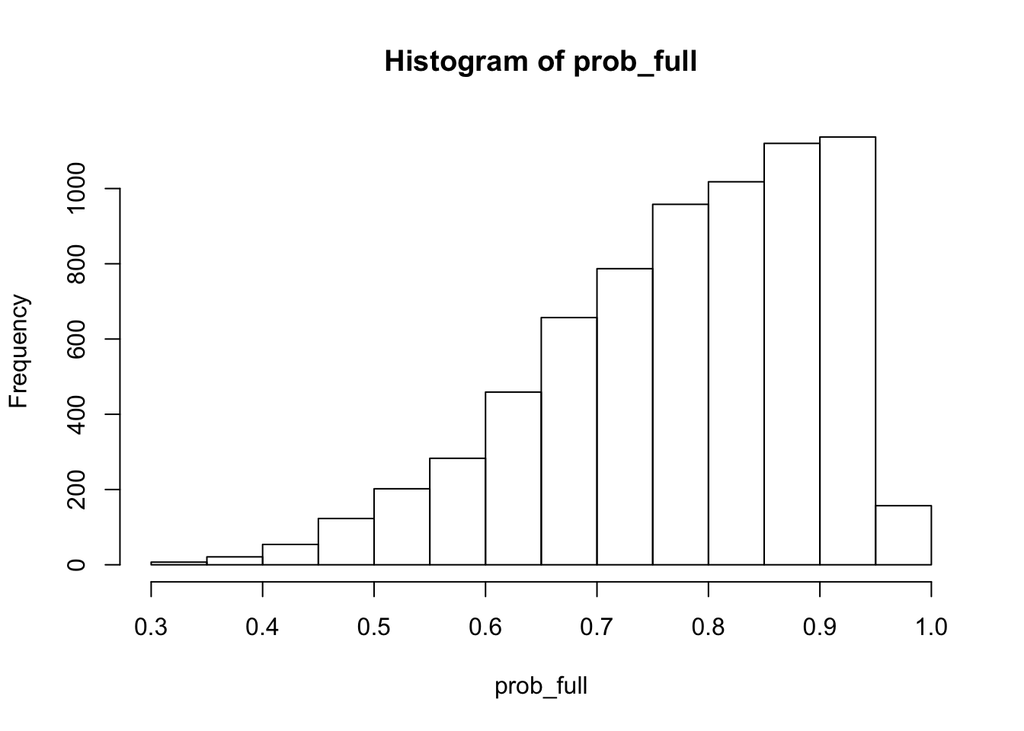

```r
hist(prob_full)
```

```r
confusionMatrix(prob_cut, loan_data.test.data$loan_status, positive = 'Good')
```

```
## Confusion Matrix and Statistics
##
##           Reference
## Prediction  Bad Good
##       Bad   826 1271
##       Good  742 4144
##
##                Accuracy : 0.7117
##                  95% CI : (0.7009, 0.7223)
##     No Information Rate : 0.7755
##     P-Value [Acc > NIR] : 1
##
##                   Kappa : 0.2608
##  Mcnemar's Test P-Value : <2e-16
##
##             Sensitivity : 0.7653
##             Specificity : 0.5268
##          Pos Pred Value : 0.8481
##          Neg Pred Value : 0.3939
##              Prevalence : 0.7755
##          Detection Rate : 0.5934
##    Detection Prevalence : 0.6997
##       Balanced Accuracy : 0.6460
##
##        'Positive' Class : Good
##
```

## 6.2 Balanced Training Data

In an attempt improve our model, we can train it with a more balanced dataset to more accurately predict Bad loans.

```
##
## Call:
## glm(formula = loan_status ~ ., family = "binomial", data = balanced_sample)
##
## Deviance Residuals:
##     Min       1Q   Median       3Q      Max
## -2.0056  -1.0733   0.5632   1.0328   2.2001
##
## Coefficients:
##                            Estimate Std. Error z value Pr(>|z|)
## (Intercept)              -2.129e+00  1.660e-01 -12.824  < 2e-16 ***
## amount                    1.465e-05  1.560e-06   9.387  < 2e-16 ***
## rate                      6.647e-01  5.439e-01   1.222  0.22171
## gradeB                    6.962e-01  5.332e-02  13.056  < 2e-16 ***
## gradeC                    1.285e+00  5.984e-02  21.470  < 2e-16 ***
## gradeD                    1.637e+00  7.455e-02  21.957  < 2e-16 ***
## gradeE                    1.942e+00  8.969e-02  21.656  < 2e-16 ***
## gradeF                    2.102e+00  1.237e-01  16.998  < 2e-16 ***
## gradeG                    2.182e+00  1.836e-01  11.887  < 2e-16 ***
## length1 to 3 years       -1.784e-03  5.190e-02  -0.034  0.97257
## length10+ years           6.024e-02  5.054e-02   1.192  0.23332
## length4 to 6 years        7.866e-02  5.467e-02   1.439  0.15021
## length7 to 9 years        1.002e-01  5.657e-02   1.771  0.07664 .
## lengthmissing             4.105e-01  7.095e-02   5.786 7.23e-09 ***
## homeOWN                   1.001e-01  4.466e-02   2.240  0.02507 *
## homeRENT                  3.100e-01  2.857e-02  10.849  < 2e-16 ***
## income                   -2.372e-06  3.579e-07  -6.629 3.37e-11 ***
## reasoncredit_card         8.351e-02  1.438e-01   0.581  0.56142
## reasondebt_consolidation  1.293e-01  1.422e-01   0.910  0.36289
## reasonhome_improvement    1.424e-01  1.509e-01   0.944  0.34512
## reasonhouse               2.901e-01  2.557e-01   1.135  0.25658
## reasonmajor_purchase      2.057e-01  1.707e-01   1.205  0.22816
## reasonmedical            -1.119e-02  1.842e-01  -0.061  0.95155
## reasonmoving             -6.800e-02  2.140e-01  -0.318  0.75073
## reasonother               1.063e-01  1.534e-01   0.693  0.48823
## reasonrenewable_energy   -6.667e-01  5.026e-01  -1.327  0.18463
## reasonsmall_business      2.557e-01  1.944e-01   1.315  0.18848
## reasonvacation            4.058e-03  2.155e-01   0.019  0.98497
## reasonwedding             4.464e-01  1.489e+00   0.300  0.76429
## debtIncRat                1.902e-02  1.508e-03  12.608  < 2e-16 ***
## delinq2yr                 3.313e-02  1.275e-02   2.598  0.00937 **
## inq6mth                   5.466e-02  1.205e-02   4.537 5.71e-06 ***
## pubRec                    5.820e-02  1.880e-02   3.095  0.00197 **
## revolRatio                1.143e-01  5.187e-02   2.204  0.02752 *
## totalAcc                  5.805e-04  1.047e-03   0.554  0.57942
## totalRevBal              -6.562e-07  2.846e-07  -2.306  0.02114 *
## ---
## Signif. codes:  0 '***' 0.001 '**' 0.01 '*' 0.05 '.' 0.1 ' ' 1
##
## (Dispersion parameter for binomial family taken to be 1)
##
##     Null deviance: 38723  on 27932  degrees of freedom
## Residual deviance: 35032  on 27897  degrees of freedom
## AIC: 35104
##
## Number of Fisher Scoring iterations: 4
```

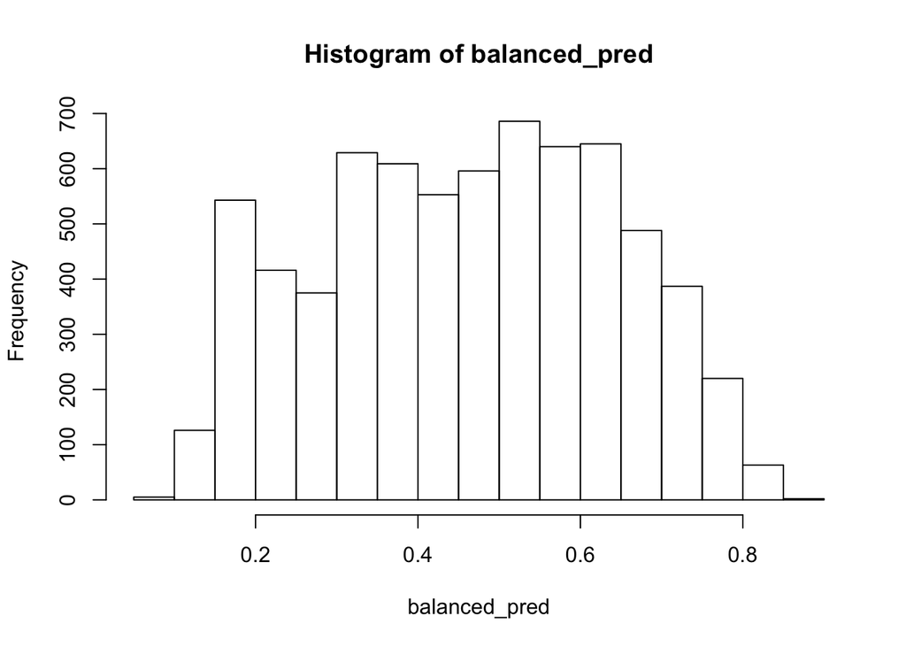

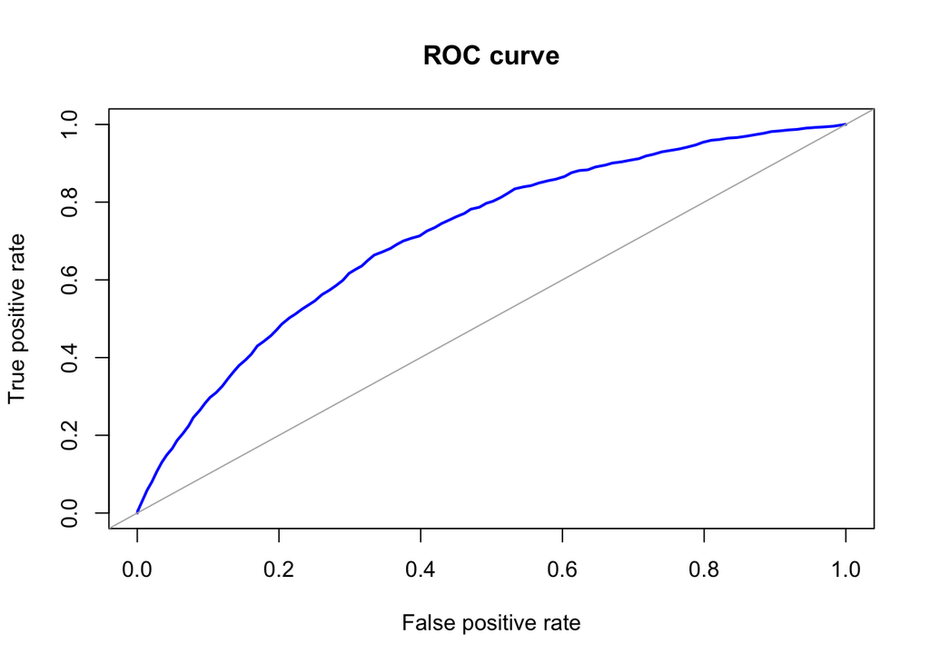

```
## Area under the curve (AUC): 0.715
```

```
## Confusion Matrix and Statistics
##
##           Reference
## Prediction  Bad Good
##       Bad   528 3610
##       Good 1040 1805
##
##                Accuracy : 0.3341
##                  95% CI : (0.323, 0.3453)
##     No Information Rate : 0.7755
##     P-Value [Acc > NIR] : 1
##
##                   Kappa : -0.2085
##  Mcnemar's Test P-Value : <2e-16
##
##             Sensitivity : 0.3333
##             Specificity : 0.3367
##          Pos Pred Value : 0.6344
##          Neg Pred Value : 0.1276
##              Prevalence : 0.7755
##          Detection Rate : 0.2585
##    Detection Prevalence : 0.4074
##       Balanced Accuracy : 0.3350
##
##        'Positive' Class : Good
##
```

This resulted in a model with an AUC of 0.715. Our models accuracy at a threshold of 0.719 is a dismal 22.53%. Adjusting the threshold to 0.52 improved the overall accuracy to 33.41% with a Sensitivity of 33.33% and a Specificity of 33.67%. The AIC of the balanced model was 35104, performing worse than our initial model with an AIC of 27270. Further adjustment of the threshold has a negative impact on either Sensitivity or Specificity with both being 33% at a threshold of 0.52.

Our initial model with an unbalanced training dataset is more accurate at predicting Good and Bad loans than our model with a balanced training dataset. We can further adjust our threshold to 0.765 to have a Sensitivity and Specificity of 66% with an overall accuracy of 67%, but remains consistent between predicting Good and Bad loans.

# 6.3 Maximized Accuracy

The maximum accuracy threshold was generated from a sequence of 0.01 to 0.99 in steps of 0.01. This threshold ignores the false-positive rate and emphasizes accuracy as opposed to predictive balance.

```r
threshold_analysis[which.max(threshold_analysis$accuracy), ]
```

|  | threshold | fp_rate | profits | losses | missed | net | accuracy |
| --- | --- | --- | --- | --- | --- | --- | --- |
| 5 | 0.05 | 0.1041761 | 11104917 | 9434658 | 792777.5 | 1670259 | 0.7786052 |

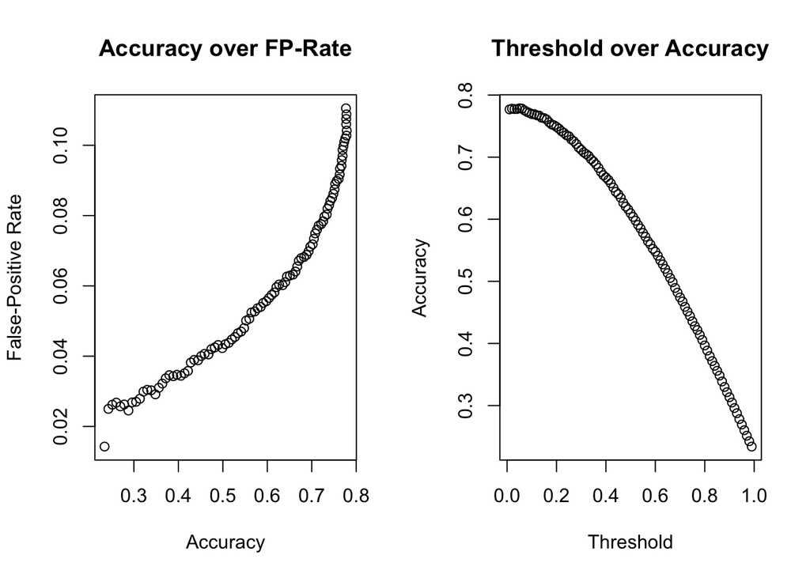

At a threshold of 0.05, we have a false-positive rate of 10.4%, a net income of $1,670,259, and an accuracy of 77.8%.

## 7. Optimizing the Threshold for Profit

With our model, we’re looking to identify a cut-off percentage on new applicants to maximize profit by preventing bad loans.

When we come across a true positive – loans in good status and we predicted it to be in good status. The loan amount is deducted from the total paid. We’ve classified loans that are only paid off as in Good status and the only income is the collected interest on the loan.

Losses include any false positives – loans in bad status that we predicted as Good. Losses are computed as the loan amount minus any amount aready paid.

The maximum accuracy threshold was generated from a sequence of 0.01 to 0.99 in steps of 0.01

```r
threshold_analysis[which.max(threshold_analysis$net), ]
```

|  | threshold | fp_rate | profits | losses | missed | net | accuracy |
| --- | --- | --- | --- | --- | --- | --- | --- |
| 25 | 0.25 | 0.08029406 | 8236014 | 5135528 | 3661681 | 3100486 | 0.7336388 |

Our analysis states that at a threshold level of 0.25, we’ll have a false-positive rate of 8%, with a net profit of $3,100,486, and an accuracy of 73.3%.

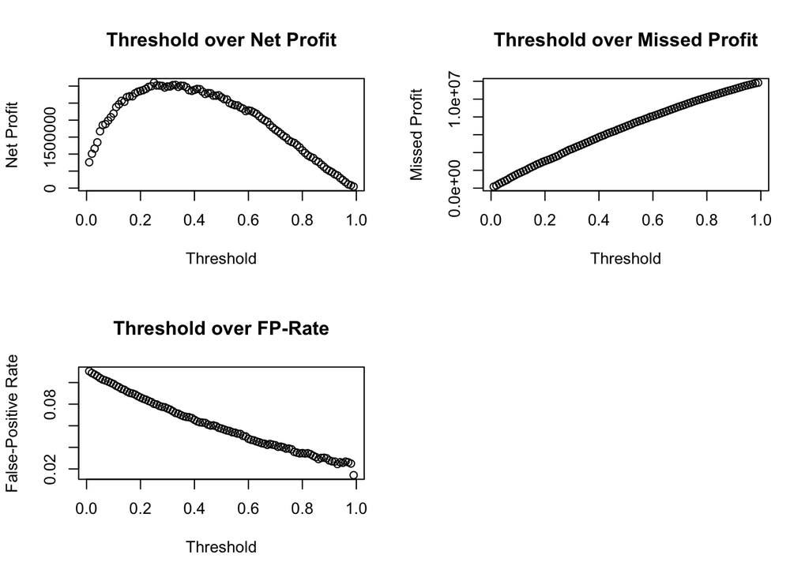

## 8. Results Summary

Using our initial model and ignoring sensitivity and specificity, the maximum accuracy is achieved at a threshold of 0.05 with an accuracy of 77.8%.

The initial model was also utilized for optimizing the threshold for profit. Ignoring accuracy and the false-positive rate, our analysis concluded that at a threshold level of 0.25, we’ll have a false-positive rate of 8%, with a net profit of $3,100,486, and an accuracy of 73.3%.